# 统计计算-思考

# 1.条件期望法课堂上的例题

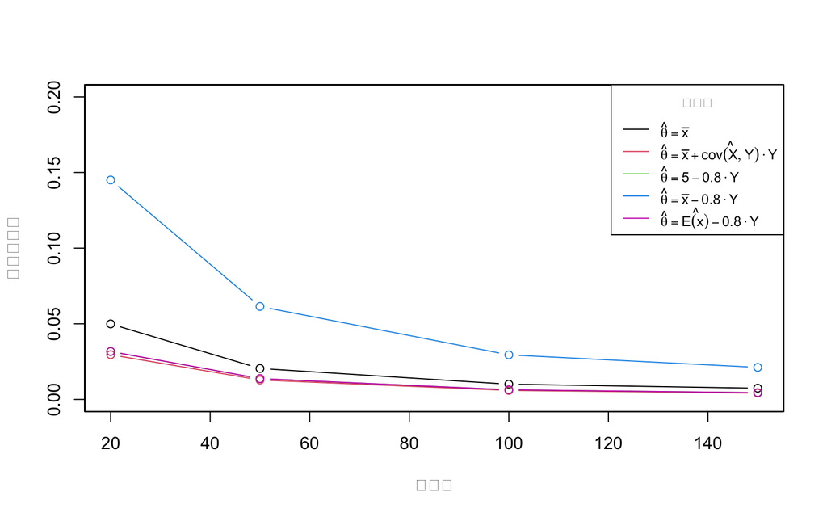

```r
library(MASS)
mu1 <- vector()
mu2 <- vector()
mu3 <- vector()
mu4 <- vector()
mu5 <- vector()
var1 <- vector()
var2 <- vector()
var3 <- vector()
var4 <- vector()
var5 <- vector()
k=1
Sigma <- matrix(c(1,-0.8,-0.8,1),2,2)
z <- mvrnorm(n=1000,c(5, 0), Sigma)
X=z[,1]
Y=z[,2]
x_bar=mean(X)
cov_hat <- cov(X,Y)

for (n in c(20,50,100,150)){
  hat_mu1<-NULL
  hat1<-NULL
  hat2<-NULL
  hat3<-NULL
  hat4 <- NULL
for (i in 1:1000){
  Sigma <- matrix(c(1,-0.8,-0.8,1),2,2)
  z <- mvrnorm(n,c(5, 0), Sigma)
  X=z[,1]
  Y=z[,2]
  hat_mu1[i]=mean(X)
  hat1[i]=mean(x_bar+cov_hat*Y)
  hat2[i]=mean(5-0.8*Y)
  hat3[i]=mean(mean(X)-0.8*Y)
  hat4[i]=mean(x_bar-0.8*Y)
  }
  mu1[k] <- mean(hat_mu1)
  mu2[k] <- mean(hat1)
  mu3[k] <- mean(hat2)
  mu4[k] <- mean(hat3)
  mu5[k] <- mean(hat4)
  var1[k] <- var(hat_mu1)
  var2[k] <- var(hat1)
  var3[k] <- var(hat2)
  var4[k] <- var(hat3)
  var5[k] <- var(hat4)
  k=k+1
  }
plot(x=c(20,50,100,150),y=var1,type = "b",col=1,ylim=c(0,0.2),ylab="",xlab="",yaxt="n",xaxt="n")
par(new=T)
plot(x=c(20,50,100,150),y=var2,type = "b",col=2,ylim=c(0,0.2),ylab="",xlab="",yaxt="n",xaxt="n")
par(new=T)
plot(x=c(20,50,100,150),y=var3,type = "b",col=3,ylim=c(0,0.2),ylab="",xlab="",yaxt="n",xaxt="n")
par(new=T)
plot(x=c(20,50,100,150),y=var4,type = "b",col=4,ylim=c(0,0.2),ylab="估计量方差",xlab="样本量")
par(new=T)
plot(x=c(20,50,100,150),y=var5,type = "b",col=6,ylim=c(0,0.2),ylab="",xlab="",yaxt="n",xaxt="n")
##X,Y方差均为1，相关系数等于协方差
legend("topright",title="估计量",c(expression(hat(theta)==bar(x)),expression(hat(theta)==bar(x)+hat(cov(X,Y))%.%Y),expression(hat(theta)==5-0.8%.%Y),expression(hat(theta)==bar(x)-0.8%.%Y),expression(hat(theta)==hat(E(x))-0.8%.%Y)),col =c(1,2,3,4,6),lty=rep(1,4),cex=0.8)
```

```r
data.frame(var1,var2,var3,var4,var5)
```

| var1 | var2 | var3 | var4 | var5 |
| --- | --- | --- | --- | --- |
| 0.049930705 | 0.029572211 | 0.031706334 | 0.14507328 | 0.031706334 |
| 0.020450664 | 0.012857824 | 0.013785729 | 0.06147744 | 0.013785729 |
| 0.010080944 | 0.005939892 | 0.006368553 | 0.02946471 | 0.006368553 |
| 0.007426929 | 0.004167124 | 0.004467851 | 0.02118676 | 0.004467851 |

```r
data.frame(mu1,mu2,mu3,mu4,mu5)
```

| mu1 | mu2 | mu3 | mu4 | mu5 |
| --- | --- | --- | --- | --- |
| 5.000166 | 4.992756 | 5.000383 | 5.000549 | 4.992769 |
| 4.995376 | 4.992724 | 5.000349 | 4.995725 | 4.992736 |
| 5.001976 | 4.994009 | 5.001680 | 5.003656 | 4.994066 |
| 4.999974 | 4.994260 | 5.001939 | 5.001914 | 4.994326 |

**分析**

观察结果可以发现，使用条件期望法可以使得方差减小，且使用各种不同具体计算形式条件期望法的方差缩减效果近似，但是使用样本均值估计X期望并使用真实相关系数的方差缩减效果不佳，甚至统计量方差变大。

综上所述，在实际应用中，不可能已知X的真实期望，在已知X,Y之间相关系数时，考虑先模拟计算估计X期望，再代入计算；在未知X,Y之间相关系数时，可以提前计算样本均值和样本相关系数作为估计代入计算。

但是可以发现，本例题中实际为控制变量法的特例，不如直接使用控制变量法的最优系数。

# 2.三种方差缩减方法代码实现

## (1) 条件期望法

例子：估计$\pi$时，设(x,y)服从D=$[-1,1]^2$上的均匀分布

$\theta$=1表示(x,y)落入单位圆C={(x,y):$x^2+y^2\le1$};

$\theta$=0表示(x,y)未落入单位圆C={(x,y):$x^2+y^2\le1$};

则$\theta$服从B(1,$\frac{\pi}{4}$)

$\hat\pi_1$=$\frac{4}{n}\sum_{i=1}^{n}\theta_i$

现使用条件期望法，使用$\alpha$=E($\theta$|X)的样本计算值代替$\theta$估计$\pi$

E($\theta$|X)=P($X^2+Y^2\le1$|X=x)=P($Y^2\le1-x^2$)=$\sqrt{1-X^2}$

$\hat\pi_2$=$\frac{4}{n}\sum_{i=1}^{n}\sqrt{1-X_i{^2}}$

```r
pi1 <- vector()
pi2 <- vector()
for(i in 1:1000){
  set.seed(i)
  x <- runif(100)
  y <- runif(100)
  theta <- (x^2+y^2<=1)
  pi1[i] <- 4*mean(theta)
  pi2[i] <- 4*mean(sqrt(1-x^2))
}
cat("E(Pi1)",mean(pi1),"E(Pi2)",mean(pi2))
```

```
## E(Pi1) 3.14404 E(Pi2) 3.143365
```

```r
cat('Var(Pi1)',var(pi1),'Var(Pi2)',var(pi2),'倍数关系',var(pi1)/var(pi2))
```

```
## Var(Pi1) 0.02610899 Var(Pi2) 0.008386288 倍数关系 3.113295
```

可以观察到两种估计量的均值相近，均接近于3.14；而原估计量方差是使用条件期望法得到的方差的3倍

## (2) 对偶变量法

进一步对(1)中利用条件期望法得到的估计量进行方差压缩，首先使用对偶变量法

h(u)=$\sqrt{1-u^2}$是u的单调函数,$\alpha$依赖于$X^2$,$X^2$与$U^2$同分布，故可取$\sqrt{1-U^2}$作为对偶变量，其中U~U(0,1)

故得到$\hat\pi_3$=$\frac{4}{n}\sum_{i=1}^{n}\frac{\sqrt{1-U_i{^2}}+\sqrt{1-(1-U_i){^2}}}{2}$

```r
pi3 <- vector()
for(i in 1:1000){
  set.seed(i)
  x <- runif(100)
  pi3[i] <- 4*mean((sqrt(1-x^2)+sqrt(1-(1-x)^2))/2)
}
cat("E(Pi2)",mean(pi2),"E(Pi3)",mean(pi3))
```

```
## E(Pi2) 3.143365 E(Pi3) 3.141832
```

```r
cat('Var(Pi2)',var(pi2),'Var(Pi3)',var(pi3),'倍数关系',var(pi2)/var(pi3))
```

```
## Var(Pi2) 0.008386288 Var(Pi3) 0.001072503 倍数关系 7.819364
```

可以观察到使用对偶变量法后得到的估计量与只使用条件期望法得到的估计量的均值相近，均接近于3.14；而仅使用条件期望法得到的估计量方差是又使用对偶变量法得到的方差的将近8倍

## (3) 控制变量法

进一步对(1)中利用条件期望法得到的估计量进行方差压缩，接下来使用控制变量法

$\alpha$依赖于$X^2$,$X^2$与$U^2$同分布，令W=$U^{2}-\frac{1}{3}$，则E(W)=0且W与$\alpha$明显负相关。可以先进行小规模的模拟估计Cov($\alpha$,W)和Var(W)得到$\hat{b}$=-$\frac{Cov(\alpha,W)}{Var(W)}$,从而利用$\beta$=$\alpha$+$\hat{b}\times$W替代$\alpha$进行估计，其中U~U(0,1)。

故得到$\hat\pi_4$=$\frac{4}{n}\sum_{i=1}^{n}[\sqrt{1-U_i^2}+\hat{b}\times(U_i^{2}-\frac{1}{3})]$

```r
pi4 <- vector()
X <- runif(1000)
w <- x^2-(1/3)
a <- sqrt(1-x^2)
b_hat <- -cov(w,a)/var(w)
for(i in 1:1000){
  set.seed(i)
  x <- runif(100)
  pi4[i] <- 4*mean(sqrt(1-x^2)+b_hat*(x^2-(1/3)))
}
cat("E(Pi2)",mean(pi2),"E(Pi4)",mean(pi4))
```

```
## E(Pi2) 3.143365 E(Pi4) 3.141977
```

```r
cat('Var(Pi2)',var(pi2),'Var(Pi4)',var(pi4),'倍数关系',var(pi2)/var(pi4))
```

```
## Var(Pi2) 0.008386288 Var(Pi4) 0.0002788768 倍数关系 30.07166
```

可以观察到使用控制变量法后得到的估计量与只使用条件期望法得到的估计量均值相近，均接近于3.14；而仅使用条件期望法得到的估计量方差是又使用控制变量法得到的方差的30倍，综合(2)中的结果，在本例中使用控制变量法的方差缩减效果更佳。

## (4) 比较对偶变量法和控制变量法

观察到(2)和(3)中的方差缩减效果比较，考虑对比两种方法。以计算$\begin{equation*}\int_{0}^{1} e^t dt\end{equation*}$

```r
pi4 <- vector()
X <- runif(1000)
b_hat <- -cov(X,1-X)/var(1-X)
for(i in 1:1000){
  set.seed(i)
  u <- runif(100)
  pi1[i] <- mean((exp(u)+exp(1-u))/2)
  pi2[i] <- mean(exp(u)-b_hat*(u-0.5))
}
cat("E(Pi1)",mean(pi1),"E(Pi2)",mean(pi2))
```

```
## E(Pi1) 1.718301 E(Pi2) 1.717936
```

```r
cat('Var(Pi1)',var(pi1),'Var(Pi2)',var(pi2),'倍数关系',var(pi2)/var(pi1))
```

```
## Var(Pi1) 3.812766e-05 Var(Pi2) 0.0004611264 倍数关系 12.09427
```